# Teste de Mann-Kendall

## Introdução

O teste de Mann-Kendall é um teste estatístico não paramétrico amplamente utilizado para detectar tendências monotônicas (crescentes ou decrescentes) em séries temporais. A estatística do teste é representada por tau de Kendall (τ), que varia de -1 a 1, indicando a direção e a força da tendência: valores positivos indicam tendência crescente e valores negativos, decrescente. O p-valor associado avalia a significância estatística dessa tendência. Quando o p-valor é menor que 0,05, rejeita-se a hipótese nula de ausência de tendência, sugerindo que há uma tendência significativa nos dados ao longo do tempo.

## 1. Preparar o Ambiente

### 1.1 Carregar os pacotes necessários

```r
if (!require("pacman")) install.packages("pacman")
library(pacman)
p_load(tidyverse, readxl, trend, ggthemes)
```

> 🔧 **Nota**: `pacman` instala automaticamente pacotes faltantes.

### 1.2 Definir o diretório de trabalho

```r
setwd("C:/Users/HP/OneDrive/Documentos/Doutorado/Tese/1) Dados")
```

> 🔧 **Altere o caminho conforme sua estrutura de pastas.**

## 2. Carregar os Dados do Excel

```r
dados <- read_excel("Medias_anuais.xlsx", sheet = 1)
```

> 🔍 **Substitua o nome do arquivo conforme o seu.**

## 3. Análise de Tendências

Temos abaixo uma função para filtrar os dados, calcular a tendência e plotar o gráfico. Para reproduzir o resultado com seus dados, é importante que a sua coluna que representa as estações esteja nomeada como **Estacao**.

```r
# Função
analise_estacao <- function(dados, estacao, parametro) {
  # Filtrar dados por estação
  dados_filtrados <- filter(dados, Estacao == estacao)

  # Calcular tendência
  tendencia <- mk.test(dados_filtrados[[parametro]])
  print(tendencia)

  # Plotar gráfico com linha de tendência
  p <- ggplot(data = dados_filtrados, aes_string(x = "Ano", y = parametro)) +
    geom_point(size = 2, color = "gray40") +
    geom_smooth(method = "lm", se = FALSE, color = "gray40",
                linetype = "dotted", linewidth = 0.8) +
    ggtitle(paste("Tendência de", parametro, "na estação", estacao,
                  "— tau =", round(as.numeric(tendencia$estimates["tau"]), 3),
                  "e p-valor =", round(tendencia$p.value, 3))) +
    labs(x = NULL, y = parametro) +
    scale_x_continuous(breaks = c(2005:2023)) +
    theme_few() +
    theme(axis.text.x = element_text(angle = 90, vjust = 0.5, hjust = 1),
          axis.title.y = element_text(size = 11, vjust = 0))

  print(p)
}
```

Abaixo temos um exemplo de uso da função, para a estação **IP-64** e parâmetro **DBO**.

```r
analise_estacao(dados, "IP-64", "DBO")
```

```
##
##  Mann-Kendall trend test
##
## data:  dados_filtrados[[parametro]]
## z = 2.1969, n = 18, p-value = 0.02803
## alternative hypothesis: true S is not equal to 0
## sample estimates:
##           S        varS         tau
##  59.0000000 697.0000000   0.3856209
```

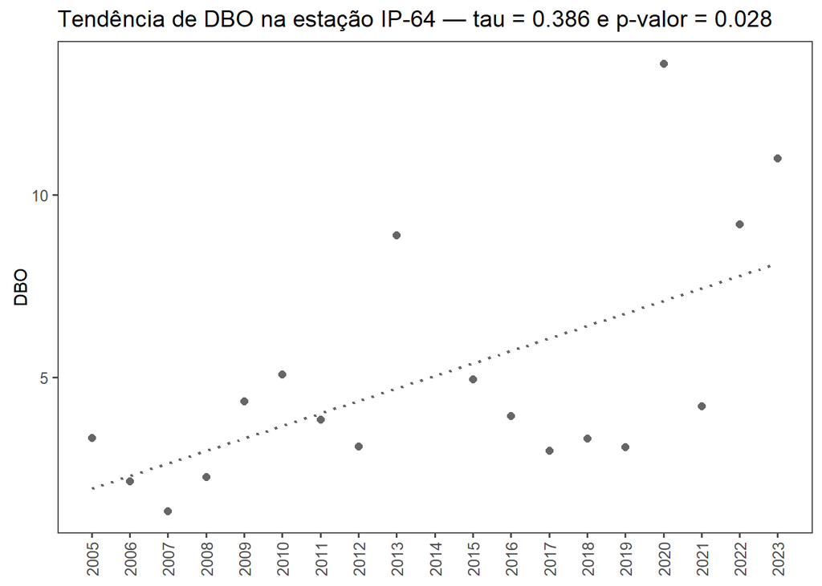

Neste caso, concluimos que a DBO na estação IP-64 apresenta tendência significativa (p-valor menor que 0,05) de aumento (tau positivo) ao longo do tempo.